# Exploration of sediment influence on seagrass

Tiff Stephens

#### The intention of this .Rmd script is to explore how sediment type (primary and secondary classifications) influences various variables that we measured in Summer 2017. The sediment type data presented here is qualitative, with sediment type classified as 1 of 10 types (1:10 :: fine:big).

#### 1. To attack this, we need the sediment_pit, biometrics, and transect dataframes from the seagrass sites. Also throw in the coordinate info. Import all of these cleaned files from the GitHub repositry.

```r
df.sedpit <- read.csv("https://raw.githubusercontent.com/APECS-ak/APECS-master-repos/master/ALL_DATA/seagrass_seaotter_pit_sediment_2017_CLEAN.csv", stringsAsFactors = FALSE, header = TRUE)

df.bio <- read.csv("https://raw.githubusercontent.com/APECS-ak/APECS-master-repos/master/ALL_DATA/seagrass_biometrics_CLEAN.csv", stringsAsFactors = FALSE, header = TRUE)

df.trans <- read.csv("https://raw.githubusercontent.com/APECS-ak/APECS-master-repos/master/ALL_DATA/seagrass_transect_2017_RAW.csv", stringsAsFactors = FALSE, header = TRUE)

df.coords <- read.csv("https://raw.githubusercontent.com/APECS-ak/APECS-master-repos/master/ALL_DATA/sites_coordinates.csv", stringsAsFactors = FALSE, header = TRUE)

df.soi <- read.csv("https://raw.githubusercontent.com/APECS-ak/APECS-master-repos/master/ALL_DATA/sea_otter_impact_index_2017.csv", stringsAsFactors = FALSE, header = TRUE)
```

#### 2. The next steps are to look at each imported DF, tidy them up, reshape them for the intended analyses, and join all reshaped DFs into one large DF (i.e. ‘df.all’). All packages used are libraried at the top of this script. The sript echoed in this .html file but can be accessed in the .Rmd file.

- df.sedpit —> df.sedpit2 (sediment + pit data sumed/averaged across transects within a site)
- df.sedpit —> df.sedpit_trans (reshapes sed + pit data to conserve transect structure within site)
- df.transect –> df.transect2 (all mean site/transect data)
- df.bio –> df.bio2 (all mean biometric data seagrass)
- df.bio –> df.mass_area (calculates mean masses per area data)
- df.soi: extracts sea otter index values

#### 3. Now all of the prepared DFs will be joined together to form the ‘df.all’, the primary DF that will be used in the following analyses.

```r
df.all <- left_join(df.coords, df.trans2, by = c("site"))
df.all <- left_join(df.all, df.sedpit2, by = c("site"))
df.all <- left_join(df.all, df.sedpit_trans, by = c("site"))
df.all <- left_join(df.all, df.bio2, by = c("site"))
df.all <- left_join(df.all, df.mass_area, by = c("site"))
df.all <- left_join(df.all, df.soi, by = c("site"))
```

We want to manipulate df.all in the following ways:

- Add a new column, where we determine Julian Day for our dates
- Reorder columns so titles for variables are easier to locate for later analysis (there are a lot of unique # variables)
- Temporarily remove some variables from the df.all (e.g. node lengths)

Here are the column names in the final df.all:

```
##  [1] "site"                     "site_name"
##  [3] "latitude"                 "longitude"
##  [5] "date"                     "julian_day"
##  [7] "depth_m"                  "so_index"
##  [9] "pits_in"                  "pits_edge"
## [11] "pits_out"                 "pits_tot_site"
## [13] "sed1_in"                  "sed1_edge"
## [15] "sed1_out"                 "sed2_in"
## [17] "sed2_edge"                "sed2_out"
## [19] "sedmean_in"               "sedmean_edge"
## [21] "sedmean_out"              "sed1_site"
## [23] "sed2_site"                "sedmean_site"
## [25] "macroalgae_percent_cover" "epiphyte_percent_cover"
## [27] "epiphyte_mass_perplant"   "epi_mass_leafarea_mg.cm2"
## [29] "flower_density_m2"        "shoot_mass_perplant"
## [31] "shoot_density_m2"         "shoot_mass_m2"
## [33] "leaf_length_mean"         "leaf_length_max"
## [35] "leaf_width_mean"          "leaf_width_max"
## [37] "leaf_area_blade"          "leaf_area_plant"
## [39] "rhi_mass_percm"           "rhi_mass_percm_m2"
## [41] "shoot_mass_m2_sd"         "rhi_mass_percm_m2_sd"
```

#### 4. Large-scale pattern in sediment type: These maps represent the numeric ordinal data, where the circle size scales with the numeric classification (larger circle = larger numeric).

```r
# Classifications: (1) mud, (2) muddy sand, (3) sandy mud, (4) sand, (5) coarse sand, (6) pebble, (7) gravel, (8) cobble, (9) boulder, (10) reef
```

#### 4A. First set of maps compare primary, secondary, and their mean for the entire site (transects averaged)

##### Red: primary sediment type; Orange: secondary sediment type; Yellow: mean of primary and secondary types

[interactive chart not shown]

#.

##### 4B. Second set of maps compare inside, edge, and outside sediments, across sites (mean primary and secondary).

##### Green: inside transect sediment type; Blue: edge transect sediment type; Purple: outside transect sediment type

[interactive chart not shown]

#.

##### 4C. Third set of maps compare #pits dug at inside, edge, and outside transects (larger circle = more pits).

##### Black: inside transect total pits; Red: edge transect total pits; Blue: outside transect total pits

[interactive chart not shown]

#.

### 5. Exploratory analysis

#### Regressions: use sediment or pit values as independent factors

There are a lot of possible plots using df.all. Tiff looked at the regressions for all of those plots but only includes results for regressions that look significant, or might with either transformation or non-linear regression.

#### 5A. Aboveground biomass:

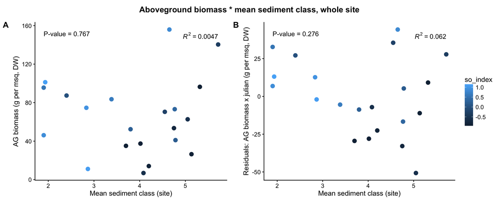

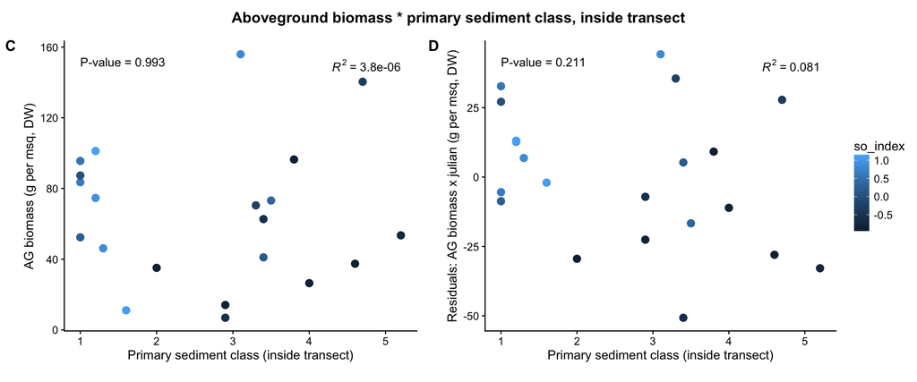

#### 5B. Belowground biomass (biomass rhizome per cm, per msq):

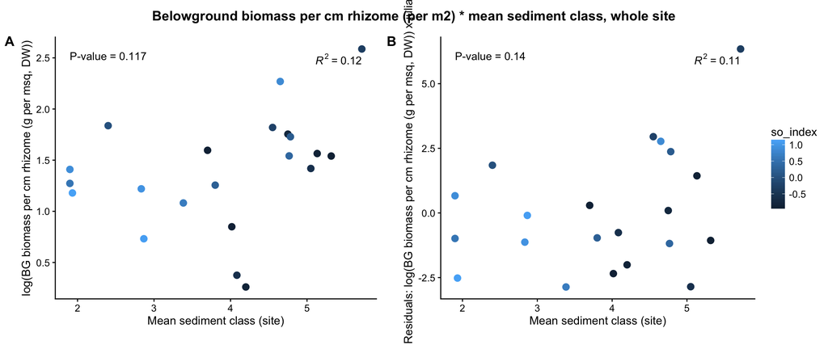

[figure not shown]

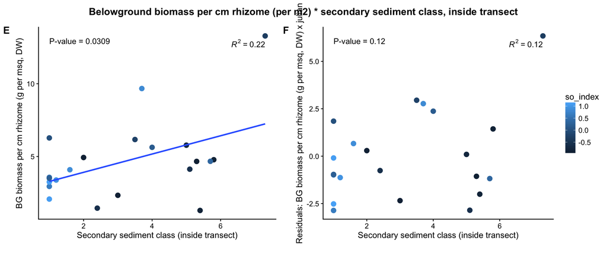

#### 5C. Belowground biomass (biomass rhizome per cm):

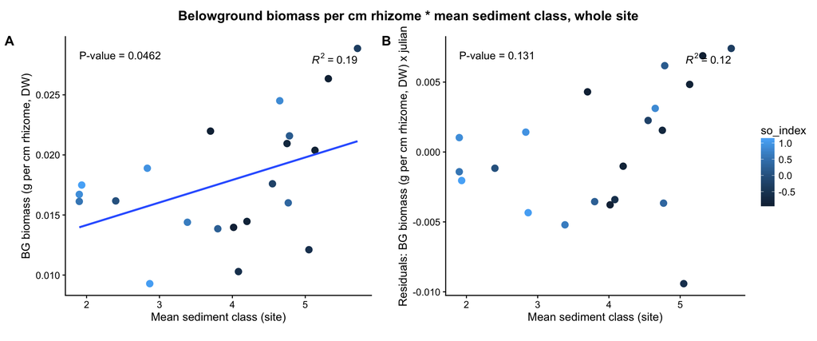

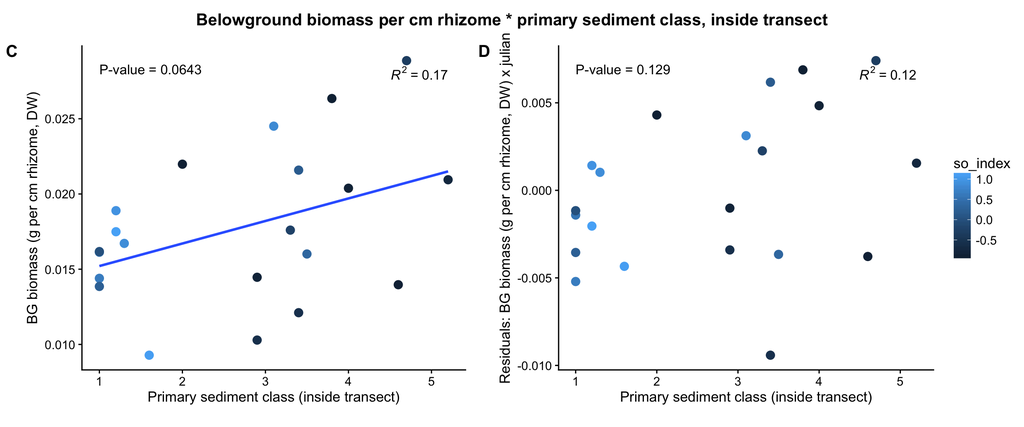

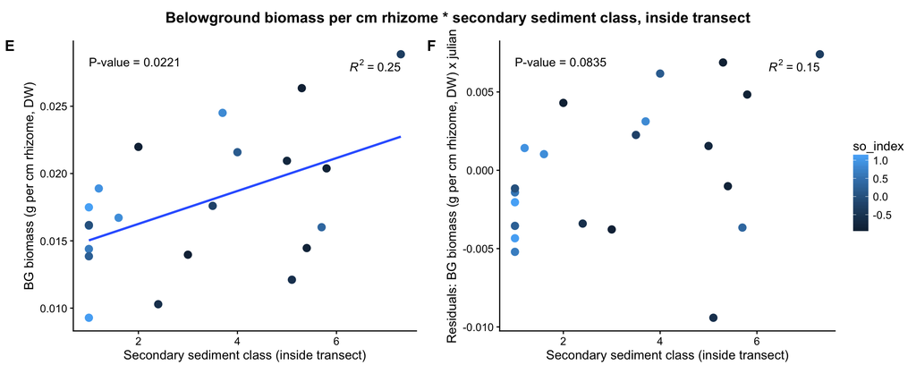

#### 5D. Epiphyte biomass (biomass):

[figure not shown]

[figure not shown]

[figure not shown]